# Mean Quadratic Error

The MQE is a measure of how close the estimator is to the true parameter value.

To compare estimator we can compute the mean quadratic Eroor, denoted by MQE :
$$\Large\text{MQE}(\hat{\theta}_{n}) =
\mathrm{Var}\left(\hat{\theta}_n\right) +
\left(b_{\theta}\left(\hat{\theta}_n\right)\right)^2$$

where $\beta_{\theta}(\hat{\theta}_{n}) = \mathbb{E}\left[\hat{\theta}_n\right] - \large\theta$ is the bias of the estimator $\hat{\theta}_n$.

We say that $\large\hat{\theta}_{n,1}$ is better than $\large\hat{\theta}_{n,2}$ if :
$$\Large\forall n, \;
\operatorname{MQE}(\hat{\theta}_{n,1})\le
\operatorname{MQE}(\hat{\theta}_{n,2})$$

# Example :

Let concider :  
- $\hat{\theta}_{n,1} = \operatorname{max}(X_k)$ and $\hat{\theta}_{n,4} = \frac{n+1}{n} \cdot \hat{\theta}_{n,1}$

We have :

- MQE$(\hat{\theta}_{n,1}) = \dfrac{2\theta^2}{(n+1)(n+2)}$
- MQE$(\hat{\theta}_{n,4}) = \dfrac{\theta^2}{n(n+1)}$

Thus, we can conclude that $\hat{\theta}_{n,4}$ is better than $\hat{\theta}_{n,1}$

**Remark**: $\hat{\theta}_{n,4}$ is the best among the two estimators we have considered. Since $\hat{\theta}_{n,4}$ is unbiased, we know that for any unbiased estimator $\hat{\theta}_n$, we have:
$$\Large\text{Cramer Rao-Bound } \leq
\mathrm{Var}\left(\hat{\theta}_n\right)$$

If $\mathrm{Var}\left(\hat{\theta}_{n,4}\right)$ equals the Cramer-Rao bound, then the estimator cannot be improved; otherwise, improvement is possible.

# Convergence Illustration in R

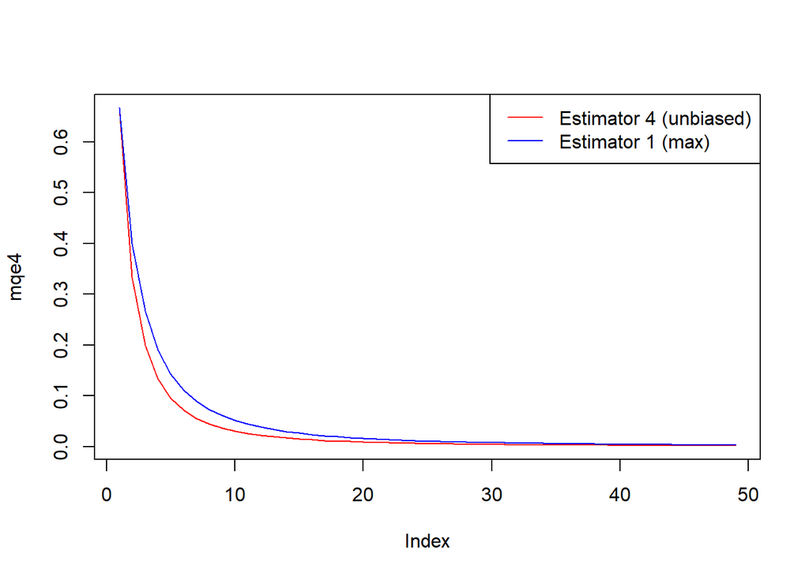

```r
theta <- 2 # assumed true value of the parameter
# MQE or Variance of the estimators
mqe1 <- 2 * theta^2 / ((2:50 + 1) * (2:50 + 2))
mqe4 <- theta^2 / (2:50 * (2:50 + 1))
plot(mqe4, type = "l", col = "red")
lines(mqe1, col = "blue")
legend("topright",
       legend = c("Estimator 4 (unbiased)", "Estimator 1 (max)"),
       col = c("red", "blue"), lty = 1)
```